# R Notebook_Random Variables

Importing Data into R

```r
library(devtools)
install_github("genomicsclass/dagdata",force=TRUE)
```

```
Downloading GitHub repo genomicsclass/dagdata@HEAD
```

[output not shown]

[output not shown]

```r
dir<-system.file(package="dagdata")
list.files(dir)
```

```
[1] "data"        "DESCRIPTION" "extdata"     "help"        "html"
[6] "Meta"        "NAMESPACE"   "script"
```

```r
list.files(file.path(dir,"extdata"))
```

```
[1] "admissions.csv"               "astronomicalunit.csv"
[3] "babies.txt"                   "femaleControlsPopulation.csv"
[5] "femaleMiceWeights.csv"        "mice_pheno.csv"
[7] "msleep_ggplot2.csv"           "README"
[9] "spider_wolff_gorb_2013.csv"
```

```r
filename<-file.path(dir,"extdata/femaleMiceWeights.csv")
dat <- read.csv(filename)
View(dat)
head(dat)
```

|  | Diet | Bodyweight |
| --- | --- | --- |
| 1 | chow | 21.51 |
| 2 | chow | 28.14 |
| 3 | chow | 24.04 |
| 4 | chow | 23.45 |
| 5 | chow | 23.68 |
| 6 | chow | 19.79 |

```r
url <- "https://raw.githubusercontent.com/genomicsclass/dagdata/master/inst/extdata/femaleControlsPopulation.csv"
filename_1<- "femaleControlsPopulation.csv"
if (!file.exists(filename_1)) download(url,destfile=filename_1)
population<-read.csv(filename_1)
population<-unlist(population)
head(population)
```

```
Bodyweight1 Bodyweight2 Bodyweight3 Bodyweight4 Bodyweight5 Bodyweight6
      27.03       24.80       27.02       28.07       23.55       22.72
```

Calculate Mean Bodyweights for Control and Treatment Groups

```r
install.packages("dplyr")
library(dplyr)
control<-filter(dat,Diet=="chow")%>%select(Bodyweight)%>%unlist
treatment<-filter(dat,Diet=="hf")%>%select(Bodyweight)%>%unlist
print(mean(control))
```

```
[1] 23.81333
```

```r
print(mean(treatment))
```

```
[1] 26.83417
```

```r
obsdiff<-mean(treatment)-mean(control)
print(obsdiff)
```

```
[1] 3.020833
```

Random variables

```r
View(population)
head(population)
```

```
Bodyweight1 Bodyweight2 Bodyweight3 Bodyweight4 Bodyweight5 Bodyweight6
      27.03       24.80       27.02       28.07       23.55       22.72
```

```r
control_population<-sample(population,12)
mean(control_population)
```

```
[1] 25.38167
```

```r
control_population_1<-sample(population,12)
mean(control_population_1)
```

```
[1] 23.97833
```

The NULL Hypothesis Now, let’s revisit our calculated average difference, obsdiff. As scientists, it’s important for us to maintain a skeptical mindset. We should question whether this observed difference can be attributed solely to the variations in diet. To address this, we might wonder what would happen if we were to provide the same diet to all 24 mice. Would we still expect to observe a difference as significant as the one we’ve calculated? Statisticians refer to this scenario as the null hypothesis. The term “null” serves as a reminder that we are approaching the question with skepticism, acknowledging the possibility that there may be no discernible difference.

Since we have access to the entire population, we can actually observe as many instances as we wish where the diet has no impact. We can achieve this by randomly selecting 24 control mice, subjecting them to the same diet, and then recording the difference in means between two randomly divided groups of 12 each.

```r
control_1<-sample(population,12)
treatment_1<-sample(population,12)
print(mean(treatment_1)-mean(control_1))
```

```
[1] -2.62
```

```r
n<-10000
null<-numeric(n)

for (i in 1:n) {
  control_2<-sample(population,12)
  treatment_2<-sample(population,12)
  null[i]<-mean(treatment_2)-mean(control_2)
}
percentage_bigger_than_obsdiff<-mean(null>=obsdiff)*100
```

Distributions

```r
install.packages("UsingR")
library(UsingR)
x<-father.son$fheight
round(sample(x,10),1)
```

```
 [1] 68.4 70.2 65.8 71.4 69.1 65.2 66.1 68.9 64.1 62.7
```

Cumulative Distribution Function

CDF: Cumulative Distribution Function ECDF: Empirical CDF

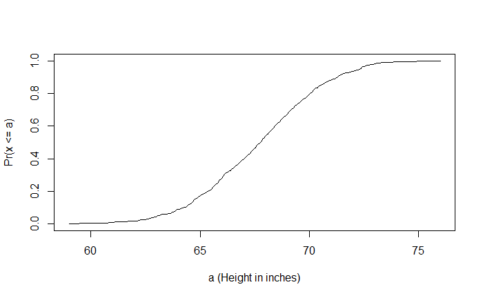

```r
smallest<-floor(min(x))
largest<-ceiling(max(x))
values<-seq(smallest,largest,len=300)
height_ecdf<-ecdf(x)
plot(values, height_ecdf(values), type="l",
     xlab="a (Height in inches)",ylab="Pr(x <= a)")
```

Histograms

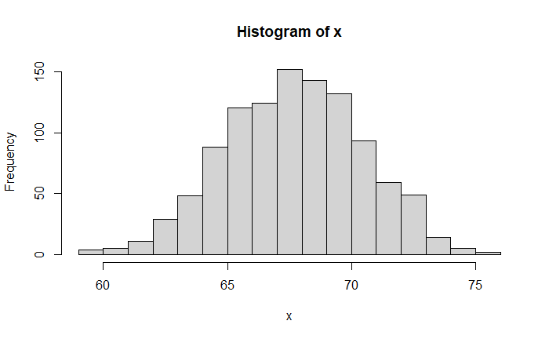

```r
hist(x)
```

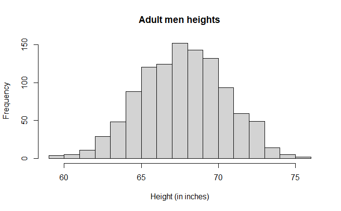

```r
bins<-seq(smallest,largest)
hist(x,breaks=bins, xlab="Height (in inches)",main="Adult men heights")
```

Probability Distribution

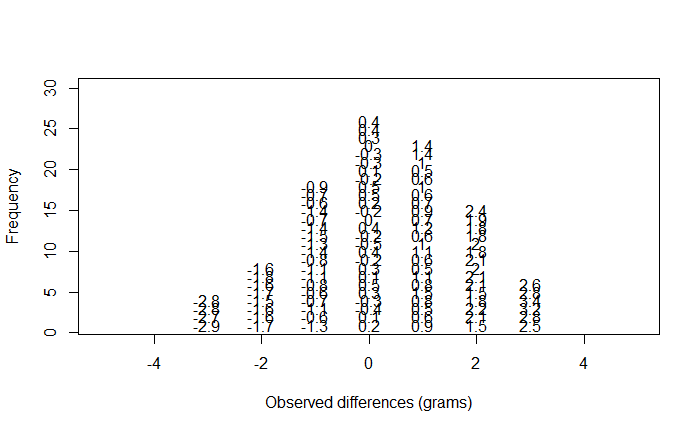

```r
n<-100
library(rafalib)
nullplot(-5,5,1,30, xlab="Observed differences (grams)", ylab="Frequency")
totals<-numeric(11)
for (i in 1:n) {
  control_3<-sample(population,12)
  treatment_3<-sample(population,12)
  nulldiff<-mean(treatment_3)-mean(control_3)
  j<-pmax(pmin(round(nulldiff)+6,11),1)
  totals[j]<-totals[j]+1
  text(j-6,totals[j],pch=15,round(nulldiff,1))
}
```

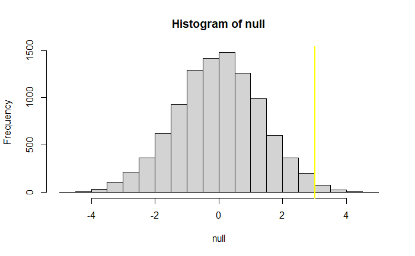

```r
hist(null,freq=TRUE)
abline(v=obsdiff,col="yellow",lwd=2)
```